Back to Article

###### Supp. Mat. 2 - Working with GBIF data

Download Notebook

# Collecting and using GBIF data

The purpose of this case study is to demonstrate how to retrieve data from GBIF, and use them to extract environmental conditions from a series of layers.

```
In [15]:
```

```julia
using SpeciesDistributionToolkit
const SDT = SpeciesDistributionToolkit
using CairoMakie
using Statistics
CairoMakie.activate!(px_per_unit=6.0)
```

We start by defining which species we want to work on:

```
In [2]:
```

```julia
tx = taxon("Akodon montensis")
```

```
GBIF taxon -- Akodon montensis
```

When this is done, we can query the initial set of occurrences. The query arguments are the same as the arguments to the GBIF occurrence API, [the documentation of which is available online](https://techdocs.gbif.org/en/openapi/).

```
In [3]:
```

```julia
occ = occurrences(tx, "occurrenceStatus" => "PRESENT", "country" => "PY", "limit" => 100, "hasCoordinate" => true)
```

```
GBIF records: downloaded 100 out of 566
```

This object is only the first page of the records, so we can start a loop to query more of them. Note that for very large number of occurrences, this can be prohibitively slow. For this reason, we are currently adding support to the download API to the **GBIF** package.

```
In [4]:
```

```julia
while length(occ) < count(occ)
    occurrences!(occ)
end
println("Retrieved $(length(occ)) occurrences")
```

```
Retrieved 566 occurrences
```

Before moving on, we will use **Phylopic** to download a silhouette for the species we work on:

```
In [12]:
```

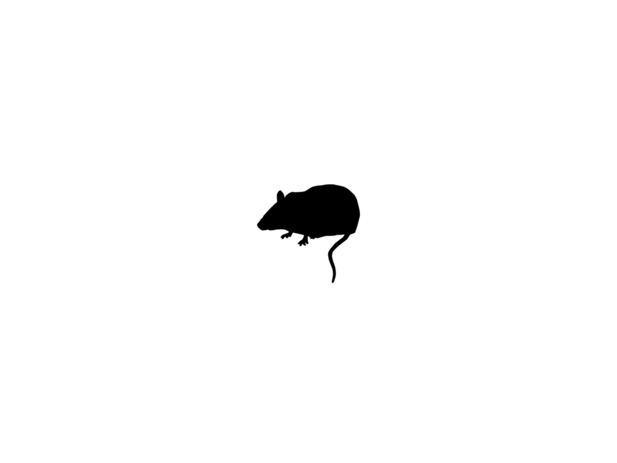

```julia
sp_uuid = Phylopic.imagesof(tx; items=1)
plt, ax, sp = silhouetteplot(0, 0, sp_uuid)
hidedecorations!(ax)
hidespines!(ax)
plt
```

The attribution of the image can be collected as well (and should be included whenever it is not a public domain dedication):

```
In [13]:
```

```julia
Phylopic.attribution(sp_uuid)
```

Image of *Akodon montensis* provided by [Edwin Price](https://creativecommons.org/publicdomain/zero/1.0/)

We will re-use the same approach to the layer download as in the previous case study, and therefore will not go quite in depth in the code.

```
In [14]:
```

```julia
provider = RasterData(CHELSA2, BioClim)
```

```
RasterData{CHELSA2, BioClim}(CHELSA2, BioClim)
```

Note, here, that we will get the bounding box for the occurrences, and only read the relevant part of the layers. We used the same approach with the bounding box for the polygon in the previous case study:

```
In [16]:
```

```julia
spatial_extent = SDT.boundingbox(occ)
```

```
(left = -58.0815, right = -54.388722, bottom = -26.755333, top = -23.813)
```

In the next code cell, we will load the raster data, and immediately convert them in the right scale (different databases store the information with different scales and offsets). Layers, here, behave as numbers for the purpose of adding and mutliplying, which leads to shorter code:

```
In [17]:
```

```julia
temperature = 0.1SDMLayer(provider; layer="BIO1", spatial_extent...) - 271
precipitation = 0.1SDMLayer(provider; layer="BIO12", spatial_extent...)
```

```
🗺️  A 354 × 444 layer with 157176 Float64 cells
   Projection: +proj=longlat +datum=WGS84 +no_defs
```

Before we move on with the figure, we can use the `layer[occurrences]` syntax to extract some of the values (and get the median). This syntax illustrates one of the ways in which **SDT** overloads the usual array indexing syntax, to rapidly extract the data stored in a layer at positions specified by occurrences.

```
In [18]:
```

```julia
temperature[occ] |> median
```

```
23.600000000000023
```

The rest of the vignette is simply data visualisation:

```
In [20]:
```

```julia
figure = Figure(; size=(600, 400))
ax =
    Axis(figure[1, 1]; xlabel="Annual mean temperature (°C)", ylabel="Annual precipitation (kg×m⁻²)")
scatter!(ax, temperature[occ], precipitation[occ], markersize=12, color=:white, strokecolor=:black, strokewidth=2)
```

```
Scatter{Tuple{Vector{Point{2, Float64}}}}
```

We finally add the silhouette:

```
In [22]:
```

```julia
silhouetteplot!(ax, 22.7, 1700.0, sp_uuid; markersize=70)
```

```
Plot{Phylopic.silhouetteplot, Tuple{Float64, Float64, PhylopicSilhouette}}
```

This is the final figure that will be shown in the manuscript:

```
In [23]:
```

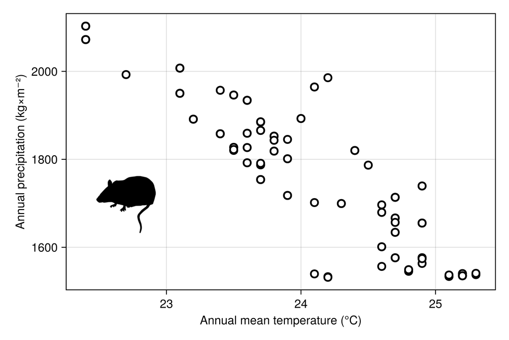

```julia
figure
```